# **Análisis Exploratorio de Datos**

### **Calidad del agua del Rio Cauca**

**Descripción:**  
Contiene información de calidad de agua en el Rio Cauca, en 19 estaciones de muestreo.  
Se miden aproximadamente 50 parámetros de calidad en el agua, entre Fisicoquímicos, Microbiológicos y Biológicos.  
Contiene datos desde el año 1990.

**Última Actualización**  
15 de julio de 2024

**Datos suministrados por**  
Corporación Autónoma Regional del Valle del Cauca

**Fuente:**  
[Calidad del agua del Río Cauca](https://www.datos.gov.co/Ambiente-y-Desarrollo-Sostenible/Calidad-del-agua-del-Rio-Cauca/d3ft-wu2b/about_data)

### **Información de los Datos:**

**Tamaño de muestra:** 2254 datos  
**Número de Variables:** 56

**NOTA:** Originalmente los datos vienen con un total de 56 variables pero para este análisis **usaré las 23 variables más representativas.**

### **Diccionario de Datos:**

(Los 23 con los que se trabajará en el presente análisis)

| **Nombre de la Variable** | **Descripción** | **Tipo de Variable** | **Escala de Medición** | **Unidades de Medición** |
| --- | --- | --- | --- | --- |
| **FECHA DE MUESTREO** | Fecha en la que se tomó la muestra de agua. | Cualitativa | Nominal | Fecha |
| **ESTACIONES** | Lugar donde se tomó la muestra. | Cualitativa | Nominal | Nombre de la estación |
| **pH** | Nivel de acidez o alcalinidad del agua. | Cuantitativa | Intervalar | - |
| **TEMPERATURA (°C)** | Temperatura del agua en el momento del muestreo. | Cuantitativa | Razón | °C |
| **COLOR (UPC)** | Medida de la coloración del agua en unidades de platino-cobalto. | Cuantitativa | Razón | UPC |
| **OXIGENO DISUELTO (mg O₂/l)** | Cantidad de oxígeno presente en el agua. | Cuantitativa | Razón | mg O₂/l |
| **DEMANDA BIOQUÍMICA DE OXÍGENO (mg O₂/l)** | Cantidad de oxígeno consumido por microorganismos. | Cuantitativa | Razón | mg O₂/l |
| **DEMANDA QUÍMICA DE OXÍGENO (mg O₂/l)** | Cantidad de oxígeno requerido para oxidar la materia orgánica. | Cuantitativa | Razón | mg O₂/l |
| **TURBIEDAD (UNT)** | Medición de la pérdida de transparencia del agua. | Cuantitativa | Razón | UNT |
| **CONDUCTIVIDAD ELÉCTRICA (µS/cm)** | Capacidad del agua para conducir electricidad. | Cuantitativa | Razón | µS/cm |
| **SÓLIDOS DISUELTOS (mg/l)** | Cantidad de materia disuelta en el agua. | Cuantitativa | Razón | mg/l |
| **NITRATOS (mg N-NO₃/l)** | Concentración de nitratos en el agua. | Cuantitativa | Razón | mg N-NO₃/l |
| **FOSFATOS (mg PO₄/l)** | Concentración de fosfatos en el agua. | Cuantitativa | Razón | mg PO₄/l |
| **CLORUROS (mg Cl/l)** | Concentración de cloruros en el agua. | Cuantitativa | Razón | mg Cl/l |
| **SULFATOS (mg SO₄/l)** | Concentración de sulfatos en el agua. | Cuantitativa | Razón | mg SO₄/l |
| **PLOMO TOTAL (mg Pb/l)** | Cantidad de plomo presente en el agua. | Cuantitativa | Razón | mg Pb/l |
| **MERCURIO (µg Hg/l)** | Cantidad de mercurio presente en el agua. | Cuantitativa | Razón | µg Hg/l |
| **CROMO TOTAL (mg Cr/l)** | Cantidad de cromo presente en el agua. | Cuantitativa | Razón | mg Cr/l |
| **CADMIO TOTAL (mg Cd/l)** | Cantidad de cadmio presente en el agua. | Cuantitativa | Razón | mg Cd/l |
| **HIERRO TOTAL (mg Fe/l)** | Cantidad de hierro presente en el agua. | Cuantitativa | Razón | mg Fe/l |
| **COLIFORMES TOTALES (NMP/100 ml)** | Cantidad de bacterias coliformes totales. | Cuantitativa | Razón | NMP/100 ml |
| **COLIFORMES FECALES (NMP/100 ml)** | Cantidad de bacterias coliformes fecales. | Cuantitativa | Razón | NMP/100 ml |
| **CAUDAL (m³/s)** | Volumen de agua que pasa por un punto del río en un segundo. | Cuantitativa | Razón | m³/s |

### Importando librerías pertinentes:

```python
import pandas as pd
import matplotlib.pyplot as plt
import numpy as np
import seaborn as sn
import warnings

warnings.filterwarnings('ignore')
```

### Carga de los datos:

```python
df = pd.read_csv("Calidad_del_agua_del_Rio_Cauca_20250327.csv")
```

```python
df
```

|  | FECHA DE MUESTREO | ESTACIONES | pH | TEMPERATURA (°C) | COLOR (UPC) | TURBIEDAD (UNT) | SOLIDOS TOTALES (mg SST/l) | SOLIDOS SUSPENDIDOS TOTALES (mg SS/l) | SOLIDOS DISUELTOS (mg SD/l) | DEMANDA BIOQUIMICA DE OXIGENO (mg O2/l) | ... | CROMO TOTAL (mg Cr/l) | CROMO DISUELTO (mg Cr/l) | NIQUEL TOTAL (mg Ni/l) | NIQUEL DISUELTO (mg Ni/l) | PLOMO TOTAL (mg Pb/l) | PLOMO DISUELTO (mg Pb/l) | MERCURIO (µg Hg/l) | COLIFORMES TOTALES (NMP/100 ml) | COLIFORMES FECALES (NMP/100 ml) | CAUDAL (m3/s) |
| --- | --- | --- | --- | --- | --- | --- | --- | --- | --- | --- | --- | --- | --- | --- | --- | --- | --- | --- | --- | --- | --- |
| 0 | 12/19/1998 12:00:00 AM | YOTOCO | 7.1 | 4.1 | NaN | 4.1 | NaN | 110 | NaN | 4.2 | ... | NaN | NaN | NaN | NaN | NaN | NaN | NaN | NaN | NaN | NaN |
| 1 | 12/19/1998 12:00:00 AM | MEDIACANOA | 7 | 2 | NaN | 2 | NaN | 130 | NaN | 3 | ... | NaN | NaN | NaN | NaN | NaN | NaN | NaN | NaN | NaN | NaN |
| 2 | 12/19/1998 12:00:00 AM | PASO DE LA TORRE | 7 | 22.9 | NaN | 3.4 | NaN | 153.3 | NaN | 5 | ... | NaN | NaN | NaN | NaN | NaN | NaN | NaN | NaN | NaN | NaN |
| 3 | 05/09/1990 12:00:00 AM | ANTES SUAREZ | 6.6 | NaN | NaN | NaN | 157.0 | 29.3 | 127.7 | 0.5 | ... | NaN | NaN | 0 | NaN | NaN | NaN | NaN | 2.4*10E4 | 23 | NaN |
| 4 | 01/10/1990 12:00:00 AM | ANTES RIO OVEJAS | 6.7 | NaN | NaN | NaN | 143.0 | 65 | 78 | 2.1 | ... | NaN | NaN | NaN | NaN | NaN | NaN | NaN | 2.4*10E4 | 24*10E4 | NaN |
| ... | ... | ... | ... | ... | ... | ... | ... | ... | ... | ... | ... | ... | ... | ... | ... | ... | ... | ... | ... | ... | ... |
| 2249 | 06/21/2023 04:45:00 PM | ANACARO | 7,87 | 24,7 | 21 | 85 | 236.0 | 115 | 121 | 2,91 | ... | < 0,108 | NaN | < 0,0499 | NaN | NaN | NaN | NaN | 2.40E+03 | 2.40E+03 | NaN |
| 2250 | 11/10/2023 12:00:00 AM | ANACARO | 7,81 | 26 | 21,1 | 60 | 208.0 | 58 | 150 | 2,32 | ... | <0,108 | NaN | <0,0499 | NaN | NaN | NaN | NaN | 9.30E+03 | 9.30E+03 | NaN |
| 2251 | 07/03/2023 12:00:00 AM | PUENTE LA VIRGINIA | 7.30 | 24.0 | 11,8 | 50 | 202.0 | 72 | 130 | 1.65 | ... | < 0,108 | NaN | < 0,0499 | NaN | NaN | NaN | NaN | 2.40E+04 | 4.30E+03 | NaN |
| 2252 | 06/21/2023 04:45:00 PM | PUENTE LA VIRGINIA | 6,2 | 24,3 | 34 | 50 | 228.0 | 67 | 161 | 3,75 | ... | < 0,108 | NaN | < 0,0499 | NaN | NaN | NaN | NaN | 9.30E+04 | 9.30E+04 | NaN |
| 2253 | 11/10/2023 12:00:00 AM | PUENTE LA VIRGINIA | 7,64 | 25,6 | 20,5 | 70 | 214.0 | 75 | 139 | 2,09 | ... | <0,108 | NaN | <0,0499 | NaN | NaN | NaN | NaN | 4.60E+04 | 2.30E+04 | NaN |

2254 rows × 56 columns

### Eligiendo únicamente las variables con las que voy a trabajar (23 en este caso):

```python
df = df[["FECHA DE MUESTREO", "ESTACIONES", "pH","TEMPERATURA (°C)","COLOR (UPC)", "OXIGENO DISUELTO (mg O2/l)",
         "DEMANDA BIOQUIMICA DE OXIGENO (mg O2/l)", "DEMANDA QUIMICA DE OXIGENO (mg O2/l)",
         "TURBIEDAD (UNT)", "CONDUCTIVIDAD ELÉCTRICA (µS/cm)", "SOLIDOS DISUELTOS (mg SD/l)",
         "NITRATOS (mg N-NO3/l)", "FOSFATOS (mg PO4/l)", "CLORUROS (mg Cl/l)",
         "SULFATOS (mg SO4/l)", "PLOMO TOTAL (mg Pb/l)", "MERCURIO (µg Hg/l)",
         "CROMO TOTAL (mg Cr/l)", "CADMIO TOTAL (mg Cd/l)", "HIERRO TOTAL (mg Fe/l)",
         "COLIFORMES TOTALES (NMP/100 ml)", "COLIFORMES FECALES (NMP/100 ml)","CAUDAL (m3/s)"]]
```

### Vistazo rápido de algunos de los datos:

```python
df.sample(10)
```

|  | FECHA DE MUESTREO | ESTACIONES | pH | TEMPERATURA (°C) | COLOR (UPC) | OXIGENO DISUELTO (mg O2/l) | DEMANDA BIOQUIMICA DE OXIGENO (mg O2/l) | DEMANDA QUIMICA DE OXIGENO (mg O2/l) | TURBIEDAD (UNT) | CONDUCTIVIDAD ELÉCTRICA (µS/cm) | ... | CLORUROS (mg Cl/l) | SULFATOS (mg SO4/l) | PLOMO TOTAL (mg Pb/l) | MERCURIO (µg Hg/l) | CROMO TOTAL (mg Cr/l) | CADMIO TOTAL (mg Cd/l) | HIERRO TOTAL (mg Fe/l) | COLIFORMES TOTALES (NMP/100 ml) | COLIFORMES FECALES (NMP/100 ml) | CAUDAL (m3/s) |
| --- | --- | --- | --- | --- | --- | --- | --- | --- | --- | --- | --- | --- | --- | --- | --- | --- | --- | --- | --- | --- | --- |
| 1416 | 05/19/2010 12:00:00 AM | RIOFRIO | 7.47 | 27.5 | 35.3 | 2.22 | 2.55 | 10.2 | 45 | 150 | ... | 7.33 | 17.7 | <0,318 | NaN | <0,300 | <0,0400 | 2.97 | 9.30E+04 | 1.50E+04 | NaN |
| 670 | 12/19/1998 12:00:00 AM | ANTES INTERCEPTOR SUR | 7.3 | 22.9 | NaN | 4.8 | 3.3 | NaN | 3.4 | 74 | ... | 2.02 | NaN | NaN | NaN | NaN | NaN | NaN | NaN | NaN | NaN |
| 984 | 10/16/2002 12:00:00 AM | LA VICTORIA | 6.5 | 25.3 | 25 | 2.51 | 3.3 | 19.3 | 42 | 180 | ... | 11.7 | 19.9 | < 0.06 | NaN | < 0.2 | < 0.04 | 2.67 | 2.40E+04 | 2.40E+04 | NaN |
| 1288 | 07/02/2008 12:00:00 AM | PUENTE GUAYABAL | 7.34 | 23.5 | 73 | 2.72 | 2.34 | 14.59 | 137 | 176.8 | ... | 5.78 | 17.84 | <0,06 | NaN | <0,2 | NaN | 7.21 | 1.50E+04 | 3.60E+03 | NaN |
| 723 | 08/18/1999 12:00:00 AM | PASO DE LA TORRE | 7.2 | 22 | 80 | 0.3 | 10.7 | 18.9 | 21 | 168 | ... | 5.45 | 19.76 | < 0.060 | NaN | < 0.200 | < 0.040 | 2.25 | >2.40E+08 | 2.40E+08 | NaN |
| 58 | 07/26/1990 12:00:00 AM | JUANCHITO | 7.1 | NaN | NaN | 5 | 0.8 | 15.6 | 33 | 95.9 | ... | 5.8 | NaN | NaN | NaN | NaN | NaN | 5.97 | 2.4*10E6 | 2.4*10E6 | NaN |
| 90 | 08/28/1991 12:00:00 AM | ANTES SUAREZ | 6.9 | NaN | NaN | 3.1 | 0.8 | 24 | 7 | 64 | ... | 8.47 | NaN | 0.47 | NaN | 0.011 | 0.005 | 0.27 | 2.40E+04 | 2.40E+04 | NaN |
| 1462 | 04/06/2011 12:00:00 AM | ANTES RIO OVEJAS | 6.72 | 20.9 | 49.4 | 5.05 | <1,94 | <5,33 | 49 | 61.8 | ... | <2,33 | 8.32 | NaN | NaN | <0,300 | NaN | 0.873 | 2.40E+04 | 4.30E+03 | NaN |
| 805 | 09/06/2000 12:00:00 AM | ANACARO | 7.5 | 23.4 | 80 | 3.2 | 6.3 | 25.7 | 257 | 147 | ... | 6.78 | 26.8 | <0.06 | NaN | <0.2 | <0.01 | 13 | 2.40E+06 | 2.40E+06 | NaN |
| 1243 | 12/12/2007 12:00:00 AM | PASO DEL COMERCIO | 7.09 | 21 | 104 | 5.87 | 2.62 | 18.99 | 129 | 98.4 | ... | 12.54 | 18.22 | <0,06 | NaN | <0,2 | <0,04 | 5.503 | 1.50E+06 | 3.60E+05 | NaN |

10 rows × 23 columns

### Información de los datos.

Se observa que a excepción de la variable 'MERCURIO (µg Hg/l)',  
todas las variables son de tipo object, por lo que procederé a cambiarlas  
según sea pertinente.

```python
df.info()
```

```
<class 'pandas.core.frame.DataFrame'>
RangeIndex: 2254 entries, 0 to 2253
Data columns (total 23 columns):
 #   Column                                   Non-Null Count  Dtype
---  ------                                   --------------  -----
 0   FECHA DE MUESTREO                        2254 non-null   object
 1   ESTACIONES                               2254 non-null   object
 2   pH                                       2208 non-null   object
 3   TEMPERATURA (°C)                         1967 non-null   object
 4   COLOR (UPC)                              1888 non-null   object
 5   OXIGENO DISUELTO (mg O2/l)               2224 non-null   object
 6   DEMANDA BIOQUIMICA DE OXIGENO (mg O2/l)  2231 non-null   object
 7   DEMANDA QUIMICA DE OXIGENO (mg O2/l)     2229 non-null   object
 8   TURBIEDAD (UNT)                          2099 non-null   object
 9   CONDUCTIVIDAD ELÉCTRICA (µS/cm)          2197 non-null   object
 10  SOLIDOS DISUELTOS (mg SD/l)              2191 non-null   object
 11  NITRATOS (mg N-NO3/l)                    2194 non-null   object
 12  FOSFATOS (mg PO4/l)                      2123 non-null   object
 13  CLORUROS (mg Cl/l)                       2172 non-null   object
 14  SULFATOS (mg SO4/l)                      1962 non-null   object
 15  PLOMO TOTAL (mg Pb/l)                    1928 non-null   object
 16  MERCURIO (µg Hg/l)                       0 non-null      float64
 17  CROMO TOTAL (mg Cr/l)                    2030 non-null   object
 18  CADMIO TOTAL (mg Cd/l)                   1892 non-null   object
 19  HIERRO TOTAL (mg Fe/l)                   2107 non-null   object
 20  COLIFORMES TOTALES (NMP/100 ml)          2035 non-null   object
 21  COLIFORMES FECALES (NMP/100 ml)          2063 non-null   object
 22  CAUDAL (m3/s)                            228 non-null    object
dtypes: float64(1), object(22)
memory usage: 405.1+ KB
```

### Cambio de tipo de datos:

```python
df["FECHA DE MUESTREO"] = pd.to_datetime(df["FECHA DE MUESTREO"], errors='coerce')
df.sample(3)
```

|  | FECHA DE MUESTREO | ESTACIONES | pH | TEMPERATURA (°C) | COLOR (UPC) | OXIGENO DISUELTO (mg O2/l) | DEMANDA BIOQUIMICA DE OXIGENO (mg O2/l) | DEMANDA QUIMICA DE OXIGENO (mg O2/l) | TURBIEDAD (UNT) | CONDUCTIVIDAD ELÉCTRICA (µS/cm) | ... | CLORUROS (mg Cl/l) | SULFATOS (mg SO4/l) | PLOMO TOTAL (mg Pb/l) | MERCURIO (µg Hg/l) | CROMO TOTAL (mg Cr/l) | CADMIO TOTAL (mg Cd/l) | HIERRO TOTAL (mg Fe/l) | COLIFORMES TOTALES (NMP/100 ml) | COLIFORMES FECALES (NMP/100 ml) | CAUDAL (m3/s) |
| --- | --- | --- | --- | --- | --- | --- | --- | --- | --- | --- | --- | --- | --- | --- | --- | --- | --- | --- | --- | --- | --- |
| 1032 | 2004-02-25 | JUANCHITO | 6.8 | 22 | NaN | 5.2 | 3.42 | 12.35 | 82 | 95.8 | ... | 8.33 | 16.1 | <0,06 | NaN | <0,2 | <0,01 | 2.67 | 2.40E+06 | 2.40E+06 | NaN |
| 1960 | 2018-06-06 | PUENTE HORMIGUERO | 7.45 | 22 | 1240 | 6.72 | 3.22 | 34.3 | 240 | 102 | ... | 3.57 | 13.3 | NaN | NaN | NaN | NaN | NaN | 4.30E+04 | 2.40E+04 | NaN |
| 2071 | 2020-03-18 | JUANCHITO | 7.25 | 24.6 | 254 | 5.26 | 1.86 | <11,1 | 37 | 92.8 | ... | 4.08 | 13.3 | <0,0499 | NaN | <0,108 | <0,0299 | 4.1 | 1.50E+04 | 9.30E+03 | 271.37 |

3 rows × 23 columns

```python
df["ESTACIONES"] = df["ESTACIONES"].astype("category")
df.sample(3)
```

|  | FECHA DE MUESTREO | ESTACIONES | pH | TEMPERATURA (°C) | COLOR (UPC) | OXIGENO DISUELTO (mg O2/l) | DEMANDA BIOQUIMICA DE OXIGENO (mg O2/l) | DEMANDA QUIMICA DE OXIGENO (mg O2/l) | TURBIEDAD (UNT) | CONDUCTIVIDAD ELÉCTRICA (µS/cm) | ... | CLORUROS (mg Cl/l) | SULFATOS (mg SO4/l) | PLOMO TOTAL (mg Pb/l) | MERCURIO (µg Hg/l) | CROMO TOTAL (mg Cr/l) | CADMIO TOTAL (mg Cd/l) | HIERRO TOTAL (mg Fe/l) | COLIFORMES TOTALES (NMP/100 ml) | COLIFORMES FECALES (NMP/100 ml) | CAUDAL (m3/s) |
| --- | --- | --- | --- | --- | --- | --- | --- | --- | --- | --- | --- | --- | --- | --- | --- | --- | --- | --- | --- | --- | --- |
| 1084 | 2005-11-02 | ANTES RIO TIMBA | 6.91 | 21 | 50.8 | 6.15 | 2.03 | 5.68 | 64 | 85.4 | ... | 4.17 | 21.67 | <0,06 | NaN | <0,2 | <0,01 | 2.26 | 9.10E+01 | 3.60E+01 | NaN |
| 648 | 1998-06-11 | ANACARO | 6.4 | 24.6 | 60 | 2.6 | 6.3 | 11.5 | 107 | 171 | ... | 3.93 | 19.113 | <0.01 | NaN | 0.038 | <0.001 | 12.51 | 2.40E+05 | 2.40E+04 | NaN |
| 2180 | 2022-07-06 | MEDIACANOA | 7,07 | 21,7 | 717 | 4,30 | 6,09 | 14,0 | >1000 | 114 | ... | NaN | NaN | NaN | NaN | NaN | NaN | 52.2 | NaN | NaN | NaN |

3 rows × 23 columns

```python
# Lista de variables numéricas (todas menos 'FECHA DE MUESTREO' y 'ESTACIONES'):

variables_numericas = [
                      "pH", "TEMPERATURA (°C)", "COLOR (UPC)", "OXIGENO DISUELTO (mg O2/l)",
                      "DEMANDA BIOQUIMICA DE OXIGENO (mg O2/l)", "DEMANDA QUIMICA DE OXIGENO (mg O2/l)",
                      "TURBIEDAD (UNT)", "CONDUCTIVIDAD ELÉCTRICA (µS/cm)", "SOLIDOS DISUELTOS (mg SD/l)",
                      "NITRATOS (mg N-NO3/l)", "FOSFATOS (mg PO4/l)", "CLORUROS (mg Cl/l)", "SULFATOS (mg SO4/l)",
                      "PLOMO TOTAL (mg Pb/l)", "MERCURIO (µg Hg/l)", "CROMO TOTAL (mg Cr/l)", "CADMIO TOTAL (mg Cd/l)",
                      "HIERRO TOTAL (mg Fe/l)", "COLIFORMES TOTALES (NMP/100 ml)", "COLIFORMES FECALES (NMP/100 ml)",
                      "CAUDAL (m3/s)"
                    ]

# Convertir las variables numéricas:

for col in variables_numericas:
    df[col] = pd.to_numeric(df[col], errors='coerce')  # Convierte y pone NaN si hay errores

# Verificar cambios
print(df.dtypes)
```

```
FECHA DE MUESTREO                          datetime64[ns]
ESTACIONES                                       category
pH                                                float64
TEMPERATURA (°C)                                  float64
COLOR (UPC)                                       float64
OXIGENO DISUELTO (mg O2/l)                        float64
DEMANDA BIOQUIMICA DE OXIGENO (mg O2/l)           float64
DEMANDA QUIMICA DE OXIGENO (mg O2/l)              float64
TURBIEDAD (UNT)                                   float64
CONDUCTIVIDAD ELÉCTRICA (µS/cm)                   float64
SOLIDOS DISUELTOS (mg SD/l)                       float64
NITRATOS (mg N-NO3/l)                             float64
FOSFATOS (mg PO4/l)                               float64
CLORUROS (mg Cl/l)                                float64
SULFATOS (mg SO4/l)                               float64
PLOMO TOTAL (mg Pb/l)                             float64
MERCURIO (µg Hg/l)                                float64
CROMO TOTAL (mg Cr/l)                             float64
CADMIO TOTAL (mg Cd/l)                            float64
HIERRO TOTAL (mg Fe/l)                            float64
COLIFORMES TOTALES (NMP/100 ml)                   float64
COLIFORMES FECALES (NMP/100 ml)                   float64
CAUDAL (m3/s)                                     float64
dtype: object
```

## **Calidad de los datos:**

### Porcentaje de Datos faltantes por variable:

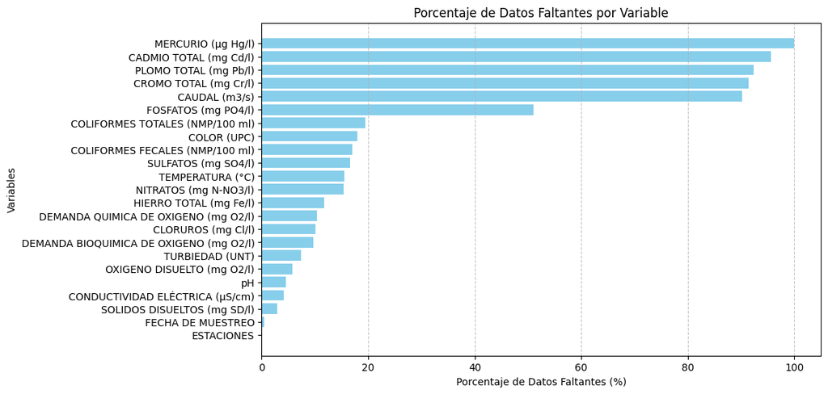

```python
# Calcular el porcentaje de datos faltantes
porcentaje_nulos = df.isnull().sum() / len(df) * 100

# Ordenar de mayor a menor
porcentaje_nulos = porcentaje_nulos.sort_values(ascending=True)

# Gráfica de barras horizontal
plt.figure(figsize=(10, 6))
plt.barh(porcentaje_nulos.index, porcentaje_nulos.values, color='skyblue')
plt.xlabel("Porcentaje de Datos Faltantes (%)")
plt.ylabel("Variables")
plt.title("Porcentaje de Datos Faltantes por Variable")
plt.grid(axis='x', linestyle='--', alpha=0.7)
plt.show()
```

Vemos que no existen datos para la variable "MERCURIO (µg Hg/l)" por lo que procederé a eliminarla.  
Las demás variables aunque tengan datos faltantes (algunas más del 80% de datos faltantes) voy a mantenerlas.  
Para un mejor análisis sería pertinente preguntar si los datos faltantes equivalen a mediciones cuyo resultado fué 0  
o si simplemente no se realizaron dichas mediciones.

```python
df = df.drop("MERCURIO (µg Hg/l)",axis=1)
```

### Errores de digitación para la variable "ESTACIONES"

Como lo dice la descripción de los datos, son en total 19 estaciones de muestreo  
por lo que se espera que en dicha variable sólo hayan 19 datos únicos.

```python
pd.Series(df["ESTACIONES"].unique())
```

```
0                    YOTOCO
1                MEDIACANOA
2          PASO DE LA TORRE
3              ANTES SUAREZ
4          ANTES RIO OVEJAS
5           ANTES RIO TIMBA
6          PASO DE LA BALSA
7          PASO DE LA BOLSA
8         PUENTE HORMIGUERO
9     ANTES INTERCEPTOR SUR
10                JUANCHITO
11        PASO DEL COMERCIO
12            PUERTO ISAACS
13                    VIJES
14                  RIOFRIO
15          PUENTE GUAYABAL
16              LA VICTORIA
17                  ANACARO
18       PUENTE LA VIRGINIA
19        PASO DE  LA BALSA
20        PASO DE  LA BOLSA
21       PUENTE  HORMIGUERO
22        ANTES INTERCEPTOR
23        PASO DE  LA TORRE
dtype: category
Categories (24, object): ['ANACARO', 'ANTES INTERCEPTOR', 'ANTES INTERCEPTOR SUR', 'ANTES RIO OVEJAS', ..., 'PUERTO ISAACS', 'RIOFRIO', 'VIJES', 'YOTOCO']
```

Se observa que hay un total de 24 datos únicos, por lo que procederé a realizar la limpieza de los datos.  
**Nota:** La limpieza la haré apoyándome de un documento técnico de la CVC sobre el tema.  
[OBJETIVOS DE CALIDAD DEL RÍO CAUCA – TRAMO VALLE DEL CAUCA DOCUMENTO TÉCNICO DE SOPORTE](https://www.cvc.gov.co/sites/default/files/2023-06/Res.%200298%20de%202023%20-%20Objetivos%20de%20calidad%20del%20r%C3%ADo%20Cuaca%20-%20Tramo%20Valle%20del%20Cauca.pdf)

```python
# Eliminar espacios extra al inicio y final
df["ESTACIONES"] = df["ESTACIONES"].str.strip()

# Reemplazar nombres inconsistentes
correcciones = {
    "PASO DE  LA BALSA": "PASO DE LA BALSA",
    "PASO DE  LA BOLSA": "PASO DE LA BOLSA",
    "PUENTE  HORMIGUERO": "PUENTE HORMIGUERO",
    "ANTES INTERCEPTOR": "ANTES INTERCEPTOR SUR",
    "PASO DE  LA TORRE": "PASO DE LA TORRE"
}

df["ESTACIONES"] = df["ESTACIONES"].replace(correcciones)

# Verificar los valores únicos después de la corrección
pd.Series(df["ESTACIONES"].unique())
```

```
0                    YOTOCO
1                MEDIACANOA
2          PASO DE LA TORRE
3              ANTES SUAREZ
4          ANTES RIO OVEJAS
5           ANTES RIO TIMBA
6          PASO DE LA BALSA
7          PASO DE LA BOLSA
8         PUENTE HORMIGUERO
9     ANTES INTERCEPTOR SUR
10                JUANCHITO
11        PASO DEL COMERCIO
12            PUERTO ISAACS
13                    VIJES
14                  RIOFRIO
15          PUENTE GUAYABAL
16              LA VICTORIA
17                  ANACARO
18       PUENTE LA VIRGINIA
dtype: object
```